# Australia Rain Fall Prediction

Arup Ghosh

3/23/2021

# Application domain: Rain Forecast

Rain Forecast depends on:

- Maximum Temperature $MT$.
- Sunshine $SS$.
- Humidity at 9AM $H9AM$. Directly influenced by Maximum Temperature ($MT$) and Sunshine ($SS$).
- Humidity at 3PM $H3PM$. Directly influenced by Sunshine ($SS$).
- Rain in Tomorrow $RT$. Directly influenced by Humidity at 9AM ($H9AM$) and Humidity at 3PM $H3PM$.
- Create the graphical model using the `model2network()` method.

## Graphical model

```r
dag.bnlearn <- model2network("[MT][SS][H9AM|MT:SS][H3PM|SS][RT|H9AM:H3PM]")
dag.bnlearn
```

```
##
##   Random/Generated Bayesian network
##
##   model:
##    [MT][SS][H3PM|SS][H9AM|MT:SS][RT|H3PM:H9AM]
##   nodes:                                 5
##   arcs:                                  5
##     undirected arcs:                     0
##     directed arcs:                       5
##   average markov blanket size:           2.80
##   average neighbourhood size:            2.00
##   average branching factor:              1.00
##
##   generation algorithm:                  Empty
```

## Graphical model Visualization

```r
#plot(dag.bnlearn)
```

## Exploring independencies using the `dsep` function of the `bnlearn` library

```r
nodes <- nodes(dag.bnlearn)
  for (n1 in nodes) {
    for (n2 in nodes) {
      if (dsep(dag.bnlearn, n1, n2))
        cat(n1, "and", n2, "are independent.\n")
    }
  }
```

```
## H3PM and MT are independent.
## MT and H3PM are independent.
## MT and SS are independent.
## SS and MT are independent.
```

- Independence is symmetric.

```r
dsep(dag.bnlearn, "MT", "MT")
```

```
## [1] FALSE
```

```r
dsep(dag.bnlearn, "SS", "SS")
```

```
## [1] FALSE
```

```r
dsep(dag.bnlearn, "H9AM", "H9AM")
```

```
## [1] FALSE
```

- Find which pairs of variables are conditionally independent given $H9AM$

```r
nodes <- nodes(dag.bnlearn)
for (n1 in nodes[nodes != "H9AM"]) {
  for (n2 in nodes[nodes != "H9AM"]) {
    if (n1 < n2) {
      if (dsep(dag.bnlearn, n1, n2, "H9AM"))
        cat(n1, "and", n2, "are independent given H9AM.\n")
    }
  }
}
```

- Find which pairs of variables are conditionally independent given $H3PM$

```r
nodes <- nodes(dag.bnlearn)
for (n1 in nodes[nodes != "H3PM"]) {
  for (n2 in nodes[nodes != "H3PM"]) {
    if (n1 < n2) {
      if (dsep(dag.bnlearn, n1, n2, "H3PM"))
        cat(n1, "and", n2, "are independent given H3PM.\n")
    }
  }
}
```

```
## MT and SS are independent given H3PM.
```

- Is there a path from $MT$ to $RT$?

```r
bnlearn::path(dag.bnlearn, from = "MT", to = "RT")
```

```
## [1] TRUE
```

- Is there a path from $SS$ to $RT$?

```r
bnlearn::path(dag.bnlearn, from = "SS", to = "RT")
```

```
## [1] TRUE
```

# Specifying the joint probability distribution

```r
distMT <- list(coef = c("(Intercept)" = 24), sd = 7)
distSS <- list(coef = c("(Intercept)" = 9), sd = 4)
distH9AM <- list(coef = c("(Intercept)" = 110, MT = -1.37, SS = -2.13), sd = 15)
distH3PM <- list(coef = c("(Intercept)" = 73.47, SS = -4.42), sd = 13.31)
distRT <- list(coef = c("(Intercept)" = 0, H9AM = 0, H3PM = 0), sd = 0.33)
dist.list = list(MT = distMT, SS = distSS, H9AM = distH9AM, H3PM = distH3PM, RT = distRT)
```

# Gaussian Bayesian networks (GBNs)

- All variables are normally distributed.
- Root nodes (i.e., nodes without any parent), are characterized by their marginal distributions.
- The conditioning effect of the parent nodes is given by an additive linear term in the mean; variance is not affected – each node has a variance that is specific to that node and does not depend on the values of the parents.
- A node’s local distribution expressed as a Gaussian linear model (an intercept and the node’s parents as explanatory variables; no interaction terms).

```r
gbn.bnlearn <- custom.fit(dag.bnlearn, dist = dist.list)
```

```r
gbn.bnlearn$SS
```

```
##
##   Parameters of node SS (Gaussian distribution)
##
## Conditional density: SS
## Coefficients:
## (Intercept)
##           9
## Standard deviation of the residuals: 4
```

```r
gbn.bnlearn$RT
```

```
##
##   Parameters of node RT (Gaussian distribution)
##
## Conditional density: RT | H3PM + H9AM
## Coefficients:
## (Intercept)         H3PM         H9AM
##           0            0            0
## Standard deviation of the residuals: 0.33
```

## rbmn R package for GBNs

- Convert the `gbn.bnlearn` (a `bn.fit` object) to `rbmn` native format.

```r
library(rbmn)
gbn.rbmn <- bnfit2nbn(gbn.bnlearn)
```

```r
gema.rbmn <- nbn2gema(gbn.rbmn)
mn.rbmn <- gema2mn(gema.rbmn)
print8mn(mn.rbmn)
```

```
##         mu   s.d.   C.MT   C.SS C.H3PM C.H9AM C.RT
## MT   24.00  7.000  1.000  0.000  0.000 -0.486    0
## SS    9.00  4.000  0.000  1.000 -0.799 -0.432    0
## H3PM 33.69 22.130  0.000 -0.799  1.000  0.345    0
## H9AM 57.95 19.737 -0.486 -0.432  0.345  1.000    0
## RT    0.00  0.330  0.000  0.000  0.000  0.000    1
```

- Assumption: The joint distribution of all nodes (i.e., the global distribution) is a **multivariate normal distribution**.

$$\begin{equation}
f(\mathrm{MT}, \mathrm{SS}, \mathrm{H9AM}, \mathrm{H3PM}, \mathrm{RT}) = f(\mathrm{MT}) \, f(\mathrm{SS}) \, f(\mathrm{H9AM} \mid \mathrm{MT}, \mathrm{SS}) \, f(\mathrm{H3PM} \mid \mathrm{SS}) \, f(\mathrm{RT} \mid \mathrm{H9AM}, \mathrm{H3PM})
\end{equation}$$

- Numeric derivation of the parameters of the **multivariate normal distribution**.

```r
gema.rbmn <- nbn2gema(gbn.rbmn)
mn.rbmn <- gema2mn(gema.rbmn)
print8mn(mn.rbmn)
```

```
##         mu   s.d.   C.MT   C.SS C.H3PM C.H9AM C.RT
## MT   24.00  7.000  1.000  0.000  0.000 -0.486    0
## SS    9.00  4.000  0.000  1.000 -0.799 -0.432    0
## H3PM 33.69 22.130  0.000 -0.799  1.000  0.345    0
## H9AM 57.95 19.737 -0.486 -0.432  0.345  1.000    0
## RT    0.00  0.330  0.000  0.000  0.000  0.000    1
```

- Structure of the `mn.rbmn` object

```r
str(mn.rbmn)
```

```
## List of 2
##  $ mu   : Named num [1:5] 24 9 33.7 58 0
##   ..- attr(*, "names")= chr [1:5] "MT" "SS" "H3PM" "H9AM" ...
##  $ gamma: num [1:5, 1:5] 49 0 0 -67.1 0 ...
##   ..- attr(*, "dimnames")=List of 2
##   .. ..$ : chr [1:5] "MT" "SS" "H3PM" "H9AM" ...
##   .. ..$ : chr [1:5] "MT" "SS" "H3PM" "H9AM" ...
```

# Training Data and Test Data split

```r
dt = sort(sample(nrow(rain.df), nrow(rain.df)*.8))
train<-rain.df[dt,]
test<-rain.df[-dt,]
```

```r
dim(train)
```

```
## [1] 6400    5
```

```r
str(train)
```

```
## 'data.frame':    6400 obs. of  5 variables:
##  $ MaxTemp     : num  22.9 28 32.3 29.7 25 26.7 31.9 30.4 18.6 21 ...
##  $ Sunshine    : num  NA NA NA NA NA NA NA NA NA NA ...
##  $ Humidity9am : int  71 45 82 55 49 48 42 48 76 65 ...
##  $ Humidity3pm : int  22 16 33 23 19 19 9 22 93 43 ...
##  $ RainTomorrow: int  0 0 0 0 0 0 1 1 1 0 ...
```

```r
library(GGally)
## Max Temperature (MT)
#mean
mean(train$MaxTemp,na.rm = TRUE)
```

```
## [1] 23.89204
```

```r
#standard deviation
sd(train$MaxTemp,na.rm = TRUE)
```

```
## [1] 7.278301
```

```r
## Sunshine (SS)
#mean
mean(train$Sunshine,na.rm = TRUE)
```

```
## [1] 8.713023
```

```r
#standard deviation
sd(train$Sunshine,na.rm = TRUE)
```

```
## [1] 3.633876
```

```r
## Humidity 9AM (Humidity9am)
model_h9am <- lm(train$Humidity9am ~ train$MaxTemp + train$Sunshine , na.rm = TRUE)
#mean
coef(model_h9am)
```

```
##    (Intercept)  train$MaxTemp train$Sunshine
##     110.556719      -1.407296      -2.074894
```

```r
#standard deviation
summary(model_h9am)$sigma
```

```
## [1] 14.92249
```

```r
## Humidity 3PM (Humidity3pm)
model_h3pm <- lm(train$Humidity3pm ~ train$Sunshine , na.rm = TRUE)
#mean
coef(model_h3pm)
```

```
##    (Intercept) train$Sunshine
##       73.70363       -4.45115
```

```r
#standard deviation
summary(model_h3pm)$sigma
```

```
## [1] 13.39848
```

```r
## Rain Tomorrow (RT)
model_rt <- lm(train$RainTomorrow ~ train$Humidity9am + train$Humidity3pm , na.rm = TRUE)
#mean
coef(model_rt)
```

```
##       (Intercept) train$Humidity9am train$Humidity3pm
##      -0.084022749      -0.004142062       0.012152970
```

```r
#standard deviation
summary(model_rt)$sigma
```

```
## [1] 0.3299504
```

- For continuous data, `bn.fit` implements only **mle** estimator.

```r
str(train)
```

```
## 'data.frame':    6400 obs. of  5 variables:
##  $ MaxTemp     : num  22.9 28 32.3 29.7 25 26.7 31.9 30.4 18.6 21 ...
##  $ Sunshine    : num  NA NA NA NA NA NA NA NA NA NA ...
##  $ Humidity9am : int  71 45 82 55 49 48 42 48 76 65 ...
##  $ Humidity3pm : int  22 16 33 23 19 19 9 22 93 43 ...
##  $ RainTomorrow: int  0 0 0 0 0 0 1 1 1 0 ...
```

```r
train$Sunshine <- as.numeric(train$Sunshine, na.rm = TRUE)
train$Humidity9am <- as.numeric(train$Humidity9am, na.rm = TRUE)
train$Humidity3pm <- as.numeric(train$Humidity3pm, na.rm = TRUE)
train$RainTomorrow <- as.numeric(train$RainTomorrow, na.rm = TRUE)
#train[] <- lapply( train, factor)
str(train)
```

```
## 'data.frame':    6400 obs. of  5 variables:
##  $ MaxTemp     : num  22.9 28 32.3 29.7 25 26.7 31.9 30.4 18.6 21 ...
##  $ Sunshine    : num  NA NA NA NA NA NA NA NA NA NA ...
##  $ Humidity9am : num  71 45 82 55 49 48 42 48 76 65 ...
##  $ Humidity3pm : num  22 16 33 23 19 19 9 22 93 43 ...
##  $ RainTomorrow: num  0 0 0 0 0 0 1 1 1 0 ...
```

```r
names(train)
```

```
## [1] "MaxTemp"      "Sunshine"     "Humidity9am"  "Humidity3pm"  "RainTomorrow"
```

```r
names(train)[names(train) == "MaxTemp"] <- "MT"
names(train)[names(train) == "Sunshine"] <- "SS"
names(train)[names(train) == "Humidity9am"] <- "H9AM"
names(train)[names(train) == "Humidity3pm"] <- "H3PM"
names(train)[names(train) == "RainTomorrow"] <- "RT"
```

# Estimating the model parameters: Correlation coefficients

```r
set.seed(4567)
raindata1 <- rbn(gbn.bnlearn, n = 200)
set.seed(1234)
raindata2 <- rbn(gbn.bnlearn, n = 20000)
str(raindata2)
```

```
## 'data.frame':    20000 obs. of  5 variables:
##  $ H3PM: num  43.01 28.7 2.48 74.36 11.54 ...
##  $ H9AM: num  63 66.6 61.5 77.7 50.6 ...
##  $ MT  : num  12.2 17.3 19.5 25.8 15.5 ...
##  $ RT  : num  0.2448 -0.0431 -0.2383 0.3542 0.1461 ...
##  $ SS  : num  4.172 10.11 13.338 -0.383 10.716 ...
```

```r
est.para <- bn.fit(dag.bnlearn, method = "mle", data = raindata1,na.rm = TRUE)
```

```r
est.para$RT <- lm(RT ~ H9AM + H3PM, data = raindata1, na.rm = TRUE)
est.para$H9AM <- lm(H9AM ~ MT + SS, data = raindata1, na.rm = TRUE)
```

- Ridge regression for the random variable $RT$

```r
library(penalized)
est.para$RT <- penalized(RT ~ H9AM + H3PM, lambda1 = 0, lambda2 = 1.5, data = raindata1)
```

```
## 12
```

```r
est.para$RT
```

```
##
##   Parameters of node RT (Gaussian distribution)
##
## Conditional density: RT | H3PM + H9AM
## Coefficients:
##  (Intercept)          H3PM          H9AM
## -0.086607212  -0.001646675   0.002177982
## Standard deviation of the residuals: 0.3154225
```

```r
est.para$RT <- lm(RT ~ H9AM + H3PM - 1, data = raindata1)
est.para$RT
```

```
##
##   Parameters of node RT (Gaussian distribution)
##
## Conditional density: RT | H3PM + H9AM
## Coefficients:
##   (Intercept)           H3PM           H9AM
##  0.0000000000  -0.0018977016   0.0009689675
## Standard deviation of the residuals: 0.3158912
```

- Parameter estimates are based only on the subset of the original data frame spanning the considered node and its parents.

```r
lmRT <- lm(RT ~ H9AM + H3PM, data = raindata1[, c("H9AM", "H3PM", "RT")])
coef(lmRT)
```

```
##  (Intercept)         H9AM         H3PM
## -0.086608818  0.002178033 -0.001646715
```

```r
confint(lmRT)
```

```
##                     2.5 %       97.5 %
## (Intercept) -2.137409e-01 0.0405233093
## H9AM        -3.465072e-05 0.0043907177
## H3PM        -3.707305e-03 0.0004138741
```

```r
cormat <- cor(raindata1[, c("RT", "H3PM", "H9AM")])
cormat
```

```
##               RT        H3PM      H9AM
## RT    1.00000000 -0.06782066 0.1047294
## H3PM -0.06782066  1.00000000 0.3463994
## H9AM  0.10472940  0.34639937 1.0000000
```

```r
library(corpcor)
invcor <- cor2pcor(cormat)
dimnames(invcor) <- dimnames(cormat)
invcor
```

```
##              RT       H3PM      H9AM
## RT    1.0000000 -0.1115829 0.1370004
## H3PM -0.1115829  1.0000000 0.3562772
## H9AM  0.1370004  0.3562772 1.0000000
```

## Structure learning

```r
stru1 <- iamb(raindata1, test = "cor")
stru1
```

```
##
##   Bayesian network learned via Constraint-based methods
##
##   model:
##     [partially directed graph]
##   nodes:                                 5
##   arcs:                                  3
##     undirected arcs:                     1
##     directed arcs:                       2
##   average markov blanket size:           1.60
##   average neighbourhood size:            1.20
##   average branching factor:              0.40
##
##   learning algorithm:                    IAMB
##   conditional independence test:         Pearson's Correlation
##   alpha threshold:                       0.05
##   tests used in the learning procedure:  68
```

```r
library(DiagrammeR)
DiagrammeR::mermaid("
  graph TB
  mt((MT)) --> h9am((H9AM))
  ss((SS)) --> h9am((H9AM))
  ss((SS)) --> h3pm((H3PM))
  h9am((H9AM)) --> rt((RT))
  h3pm((H3PM)) --> rt((RT))
")
```

[interactive chart not shown]

## Network scores

- Bayesian Gaussian equivalent score (BGe) – posterior probability score in common use is an uniform prior over the space of DAGs and of the parameters.

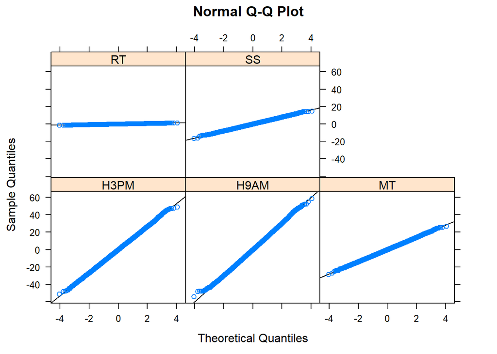

```r
# applied to all nodes, each node in a separate panel
gbn.fit <- bn.fit(dag.bnlearn, raindata2)
bn.fit.qqplot(gbn.fit)
```

```r
score(dag.bnlearn, data = raindata2, type = "bic-g")
```

```
## [1] -292312.5
```

```r
score(dag.bnlearn, data = raindata2, type = "bge")
```

```
## [1] -292363.5
```

```r
print8nbn(gbn.rbmn)
```

```
## =====Nodes===[parents]   = Exp. (sd.dev)
## -----------------------------------------------
## --------MT---[-]  = 24  (7)
## --------SS---[-]  = 9  (4)
## ------H3PM---[SS]  = 73.47 + -4.42*SS  (13.31)
## ------H9AM---[MT,SS]  = 110 + -1.37*MT + -2.13*SS  (15)
## --------RT---[H3PM,H9AM]  = 0*H3PM + 0*H9AM  (0.33)
```

```r
print8gema(gema.rbmn)
```

```
##         mu    E1     E2    E3 E4   E5
## MT   24.00  7.00   0.00  0.00  0 0.00
## SS    9.00  0.00   4.00  0.00  0 0.00
## H3PM 33.69  0.00 -17.68 13.31  0 0.00
## H9AM 57.95 -9.59  -8.52  0.00 15 0.00
## RT    0.00  0.00   0.00  0.00  0 0.33
```

/*——————————————————————————————————————-*/

- `condi4joint()` in rbmn is used to obtain the conditional joint distribution of one or more nodes when the values of the others are fixed.

-For example, compute the distribution of RT when SS is fixed to 80

```r
print8mn(condi4joint(mn.rbmn, par = "RT", pour = "SS", x2 = 80))
```

```
##    mu s.d.
## RT  0 0.33
```

- Compute the distribution of of SS when RT is fixed to 80.

```r
print8mn(condi4joint(mn.rbmn, par = "SS", pour = "RT", x2 = 80))
```

```
##    mu s.d.
## SS  9    4
```

```r
unlist(condi4joint(mn.rbmn, par = "RT", pour = "SS", x2 = NULL))
```

```
##  mu.RT    rho  gamma
## 0.0000 0.0000 0.1089
```

## Approximate inference

```r
nbs <- 4
VG <- rnorm(nbs, mean = 50, sd = 10)
VE <- rnorm(nbs, mean = 50, sd = 10)
VV <- rnorm(nbs, mean = -10.355 + 0.5 * VG + 0.707 * VE, sd = 5)
VN <- rnorm(nbs, mean = 45 + 0.1 * VV, sd = 9.95)
cbind(VV, VN)
```

```
##            VV       VN
## [1,] 37.95198 41.35186
## [2,] 52.16266 40.36850
## [3,] 53.05536 63.83801
## [4,] 48.11759 22.25497
```

For GBNs, a quicker and easier way is to use bnlearn

```r
sim <- rbn(gbn.bnlearn, n = 4)
sim[, c("SS", "H9AM")]
```

```
##         SS     H9AM
## 1 11.80437 48.78623
## 2 13.57646 44.99981
## 3 11.50448 61.55875
## 4 14.70498 62.99951
```

```r
set.seed(4567)
raindata1 <- rbn(gbn.bnlearn, n = 200)
set.seed(1234)
raindata2 <- rbn(gbn.bnlearn, n = 20000)
str(raindata2)
```

```
## 'data.frame':    20000 obs. of  5 variables:
##  $ H3PM: num  43.01 28.7 2.48 74.36 11.54 ...
##  $ H9AM: num  63 66.6 61.5 77.7 50.6 ...
##  $ MT  : num  12.2 17.3 19.5 25.8 15.5 ...
##  $ RT  : num  0.2448 -0.0431 -0.2383 0.3542 0.1461 ...
##  $ SS  : num  4.172 10.11 13.338 -0.383 10.716 ...
```

- Imposing restrictions on simulation is a common practice.
- How do we obtain the distribution of a pair of variables conditioned on another variable? For example, $H9AM, H3PM \mid SS = 40$. This can be done using GBN.
- What are the values of H9AM and H3PM associated with a good rain fall next day? That is, $\mathrm{N}, \mathrm{W} \mid \mathrm{RT} > 80$
- A naive but correct approach is: make a simulation with a high number of draws, and retain only those satisfying the condition (i.e., $\mathrm{RT} > 80)$.
- This approach is not feasible when the probability of generating observations satisfying the condition is very small.
- However, we will try with `cpquery()` and `cpdist()`.

```r
head(cpdist(gbn.bnlearn, nodes = c("RT", "H9AM", "H3PM"), evidence = (RT > 80)))
```

```
## [1] RT   H9AM H3PM
## <0 rows> (or 0-length row.names)
```

- In the case of continuous variables, only intervals will have probability. This forces us to discard all the generated samples.
- More advanced simulation approaches are needed – **likelihood weighting** (lw) is one such simple approach.
- lw is accessed from `cpdist()` by setting the method to “lw.”

```r
head(cpdist(gbn.bnlearn, nodes = c("H9AM"), evidence = list(MT = 10, SS = 90), method = "lw"))
```

```
##         H9AM
## 1  -97.79441
## 2  -97.20968
## 3  -95.30294
## 4 -106.91206
## 5 -100.18131
## 6 -106.97664
```

- We compute the probability of a specific event using the **likelihood weighting** via the `cpquery()`.

```r
cpquery(gbn.bnlearn, event = (H9AM > 70), evidence = list(MT = 10, SS = 90), method = "lw")
```

```
## [1] 0
```

# Plotting GBNs

```r
library(igraph)
igraph.options(print.full = TRUE)
# define vertices and edges
dag0.igraph <- graph.formula(MT-+H9AM, SS-+H9AM, SS-+H3PM, H9AM-+RT, H3PM-+RT)
dag0.igraph
```

```
## IGRAPH eb93d2b DN-- 5 5 --
## + attr: name (v/c)
## + edges from eb93d2b (vertex names):
## [1] MT  ->H9AM H9AM->RT   SS  ->H9AM SS  ->H3PM H3PM->RT
```

For convenience, convert a **bn** or **bn.fit** object into an **igraph** graph object.

```r
#dag.igraph <- igraph.from.graphNEL(as.graphNEL(dag.bnlearn))
```

```r
# print nodes
#V(dag.igraph)
# print edges
#E(dag.igraph)
```

```r
# par(mfrow = c(2, 2), mar = rep(3, 4), cex.main = 2)
# plot(dag.igraph, main = "\n1: defaults")
#
# dag2 <- dag.igraph
# V(dag2)$label <- V(dag2)$name
# plot(dag2, main = "\n2: with labels")
#
# ly <- matrix(c(2, 3, 1, 1, 2, 3,
#                1, 4, 4, 2, 3, 2), 6)
# plot(dag2, layout = ly, main = "\n3: positioning")
#
# colo <- c("black", "darkgrey", "darkgrey", rep(NA, 3))
# lcolo <- c(rep("white", 3), rep(NA, 3))
# par(mar = rep(0, 4), lwd = 1.5)
# plot(dag2, layout = ly, frame = TRUE,
#      main = "\n4: final",
#      vertex.color = colo, vertex.label.color = lcolo,
#      vertex.label.cex = 3, vertex.size = 50,
#      edge.arrow.size = 0.8, edge.color = "black")
```

## Plotting conditional probability distributions

- Recall that we used `bn.fit.barchart()` of `bnlearn` package for discrete BNs; however, no such function for GBNs.
- The parents of a node in a GBN are defined over $\mathbb{R}$ and the corresponding local distribution is difficult to plot. However, common diagnostic plots for linear regression models are available (they are based on the **lattice** graphics, and apply to **bn.fit** object).
  - **bn.fit.qqplot**: a quantile-quantile plot of the residuals.
  - **bn.fit.histogram**: a histogram of the residuals, with theoretical normal density superimposed.
  - **bn.fit.xyplot**: residuals against the fitted values.

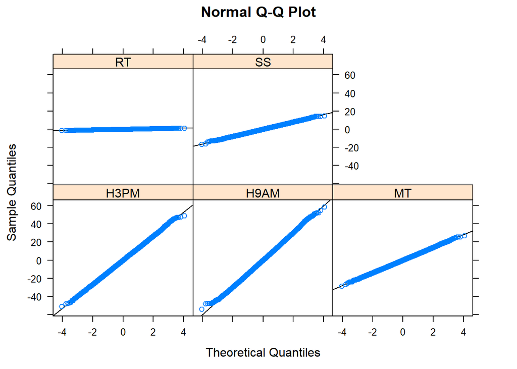

```r
# applied to all nodes, each node in a separate panel
gbn.fit <- bn.fit(dag.bnlearn, raindata2)
bn.fit.qqplot(gbn.fit)
```

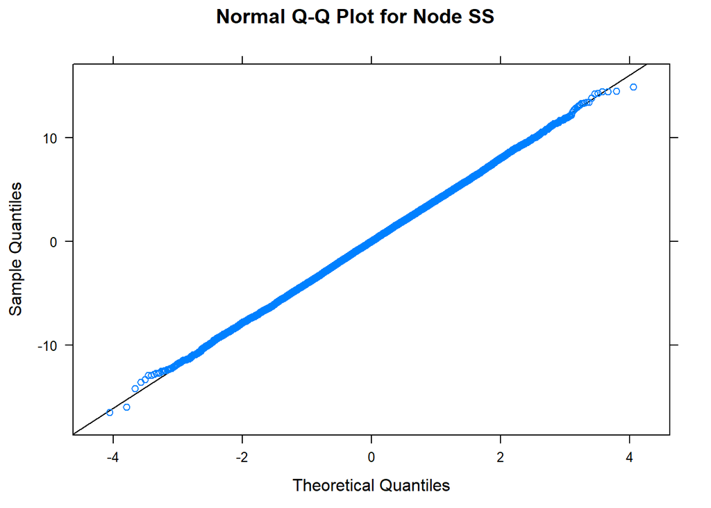

```r
# applied to a single node
bn.fit.qqplot(gbn.fit$SS)
```

- The above plots require the *residuals* and the *fitted values* to be stored in the bn.fit object; GBNs created with **custom.fit()** produce an error unless both quantities have been provided by the user.

```r
try(bn.fit.qqplot(gbn.bnlearn))
```

```
## Error in lattice.gaussian.backend(fitted = fitted, type = "qqplot", xlab = xlab,  :
##   no residuals present in the bn.fit object.
```

```r
# closed form solution
RT.MTH9AM <- condi4joint(mn.rbmn, par = "RT", pour = c("MT", "H9AM"), x2 = NULL)
RT.MTH9AM$rho
```

```
##    MT H9AM
## RT  0    0
```

```r
dsep(gbn.bnlearn, "MT", "RT", "H9AM")
```

```
## [1] FALSE
```

- Produce a plot providing insight on the distribution of C when both E and V vary.
- We will replace the third dimension with the size of the points representing each simulated observation.

[figure not shown]

```r
set.seed(5678)
raindata3 <- cpdist(gbn.bnlearn, nodes = c("MT", "RT", "H9AM"), evidence = TRUE, n = 1000)
plot(raindata3$H9AM, raindata3$RT, type = "n", main = "RT | H9AM, SS; SS is the point size")
cexlim <- c(0.1, 2.4)
cexE <- cexlim[1] + diff(cexlim) / diff(range(raindata3$SS)) * (raindata3$SS - min(raindata3$SS))
points(raindata3$V, raindata3$C, cex = cexE)
cqa <- quantile(raindata3$C, seq(0, 1, 0.1))
abline(h = cqa, lty = 3)
```

[figure not shown]

```r
set.seed(1234)
raindata3 <- cpdist(gbn.bnlearn, nodes = c("MT", "RT", "H9AM"), evidence = TRUE, n = 1000)
plot(raindata3$H9AM, raindata3$RT, type = "n", main = "RT | H9AM, SS; H9AM is the point size")
cexlim <- c(0.1, 2.4)
cexV <- cexlim[1] + diff(cexlim) / diff(range(raindata3$H9AM)) * (raindata3$H9AM - min(raindata3$H9AM))
points(raindata3$E, raindata3$C, cex = cexV)
cqa <- quantile(raindata3$C, seq(0, 1, 0.1))
abline(h = cqa, lty = 3)
```

# Recovering model parameters using the sampled data

Compare the recovered model parameters with the corresponding model parameters specified by the domain experts.

```r
dim(raindata2)
```

```
## [1] 20000     5
```

```r
round(head(raindata2), 2)
```

```
##    H3PM  H9AM    MT    RT    SS
## 1 43.01 62.95 12.18  0.24  4.17
## 2 28.70 66.64 17.31 -0.04 10.11
## 3  2.48 61.48 19.46 -0.24 13.34
## 4 74.36 77.66 25.83  0.35 -0.38
## 5 11.54 50.63 15.46  0.15 10.72
## 6 29.44 72.41 13.15 -0.53 11.02
```

```r
mean(raindata2$MT, na.rm = TRUE)
```

```
## [1] 24.0528
```

```r
var(raindata2$MT,na.rm = TRUE)
```

```
## [1] 49.18508
```

## Mean and variance of the r.v. SS ( SUnshine)

```r
mean(raindata2$SS, na.rm = TRUE)
```

```
## [1] 8.996738
```

```r
var(raindata2$SS, na.rm = TRUE)
```

```
## [1] 15.89775
```

## Mean and variance of the r.v. H9AM (Humidity at 9AM)

- We estimate the the conditional distribution $H9AM \mid SS, MT$ using a linear regression.

```r
MTSS.H9AM.regression <- lm(raindata2$H9AM ~ raindata2$SS + raindata2$MT, data=raindata2)
coef(MTSS.H9AM.regression)
```

```
##  (Intercept) raindata2$SS raindata2$MT
##   110.064157    -2.108973    -1.380030
```

```r
summary(MTSS.H9AM.regression)$sigma
```

```
## [1] 15.01556
```

## Mean and variance of the r.v. H9AM (Humidity at 9AM)

```r
SS.H9AM.regression <- lm(raindata2$H9AM ~ raindata2$SS +raindata2$MT  , data=raindata2)
coef(SS.H9AM.regression)
```

```
##  (Intercept) raindata2$SS raindata2$MT
##   110.064157    -2.108973    -1.380030
```

```r
summary(SS.H9AM.regression)$sigma
```

```
## [1] 15.01556
```

## Mean and variance of the r.v. H3PM (Hudimity at 3PM)

$$H3PM = \beta_0 + \beta_1 \cdot SS$$

```r
SS.H3PM.regression <- lm(raindata2$H3PM ~ raindata2$SS, data=raindata2)
coef(SS.H3PM.regression)
```

```
##  (Intercept) raindata2$SS
##    73.545000    -4.436073
```

```r
summary(SS.H3PM.regression)$sigma
```

```
## [1] 13.30584
```

## Mean and variance of the r.v. RT (Rainfall prediction)

```r
H9AM.H3PM.RT.regression <- lm(raindata2$RT ~ raindata2$H3PM + raindata2$H9AM, data=raindata2)
coef(H9AM.H3PM.RT.regression)
```

```
##    (Intercept) raindata2$H3PM raindata2$H9AM
##   4.884254e-03  -3.759113e-05   7.828434e-06
```

```r
summary(H9AM.H3PM.RT.regression)$sigma
```

```
## [1] 0.3293263
```

1. Did you state your project goal? That is, what question(s) will this project address?

This project goal is to forecast the Rain in Australia based on the weather conditions. Based on the temparatures and Humidity, we can predict next day rain.

2. Did you describe the dataset? What is the motivation for selecting the dataset you have chosen? List the size of your dataset and the total number of variables. Which are predictive variables and which is the target variable?

3. What did you learn about the dataset through exploratory data analysis? Which variables are highly correlated?

4. What domain knowledge guided you to build the initial model?

General information about weather conditions as i follow them everyday.

5. Did you use the data to learn the model parameters?

Yes

6. Did you use the data for structure learning? How did you assess the quality of the learned structure of the Bayesian network?

By running the test cases and calculating the scores.

7. How does the learned structure of the model compares with the original model?

8. Did you illustrate answering queries (i.e., exact and approximate inference) using the model?

yes.

9. Did you interpret the answers to the queries?

I was able to understand the results and correlate them to the actual data.

10. Did you reflect on the project? Did the project answer your original question(s), which motivated the project?

Its very helpful to work on the real world project as it gave insights into how the prediction and modelling works.

This project greatly helped me to absorb the key concepts from the class room learning to the real world. Also it helps my understanding about further projects i work in future.